# Homework(10.12)

Hwang Seong-Yun

2020 10 12

## 연습문제 5.5

## 50명의 피부 흑색종(skin melanoma) 환자들에 대해 치료 후 사망시간 구간표를 얻었다. 30명의 환자가 중도절단되었다고 한다.

### (1) R을 이용하여 생명표를 작성하시오.

```r
library(KMsurv)
tis <- 0:6
ninit <- 50                  # number of initial risk set
ncen <- c(0,1,4,5,3,17)     # censored
nevent <- c(9,6,2,1,2,0)   # observed
a<-lifetab(tis, ninit, ncen, nevent)
a
```

```
##     nsubs nlost nrisk nevent      surv        pdf     hazard    se.surv
## 0-1    50     0  50.0      9 1.0000000 0.18000000 0.19780220 0.00000000
## 1-2    41     1  40.5      6 0.8200000 0.12148148 0.16000000 0.05433231
## 2-3    34     4  32.0      2 0.6985185 0.04365741 0.06451613 0.06509500
## 3-4    28     5  25.5      1 0.6548611 0.02568083 0.04000000 0.06795340
## 4-5    22     3  20.5      2 0.6291803 0.06138344 0.10256410 0.06997313
## 5-6    17    17   8.5      0 0.5677968         NA         NA 0.07541644
##         se.pdf  se.hazard
## 0-1 0.05433231 0.06561081
## 1-2 0.04647608 0.06511037
## 2-3 0.03016580 0.04559605
## 3-4 0.02531291 0.03999200
## 4-5 0.04179432 0.07242835
## 5-6         NA         NA
```

### (2) 생존함수 그래프를 그리시오.

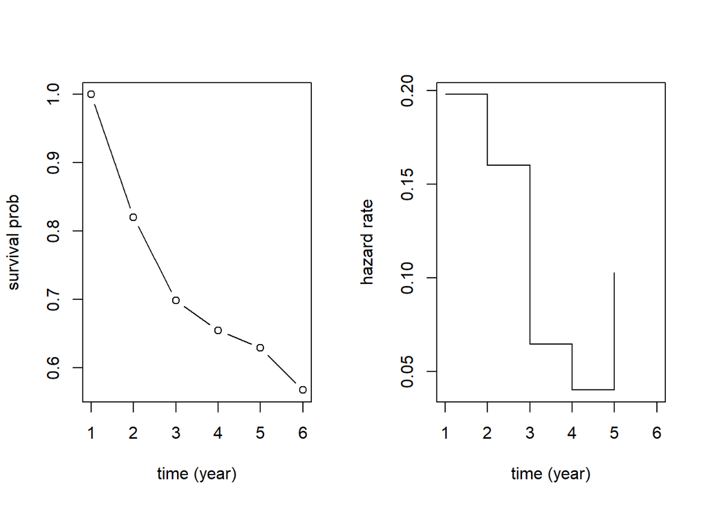

```r
par(mfrow=c(1,2))
plot(a$surv, type="b", xlab="time (year)", ylab="survival prob")
plot(a$hazard, type="s",xlab="time (year)", ylab="hazard rate")
```

```r
par(mfrow=c(1,1))
```

## 연습문제 5.7

## 다음의 pbc 데이터(survival 패키지에 내장됨)에 대해 R을 이용하여 다음과 같이 Kaplan-Meier 생존함수를 구하고 물음에 답하시오.

```r
library(survival)
data(pbc)
fit <- survfit(Surv(time,(status==2))~1, data=pbc)
summary(fit)
```

```
## Call: survfit(formula = Surv(time, (status == 2)) ~ 1, data = pbc)
##
##  time n.risk n.event survival std.err lower 95% CI upper 95% CI
##    41    418       2    0.995 0.00338        0.989        1.000
##    43    416       1    0.993 0.00413        0.985        1.000
##    51    415       1    0.990 0.00476        0.981        1.000
##    71    414       1    0.988 0.00532        0.978        0.999
##    77    413       1    0.986 0.00582        0.974        0.997
##    94    412       1    0.983 0.00628        0.971        0.996
##   110    411       1    0.981 0.00670        0.968        0.994
##   111    410       1    0.978 0.00710        0.965        0.992
##   130    409       1    0.976 0.00747        0.962        0.991
##   131    408       1    0.974 0.00783        0.958        0.989
##   140    407       1    0.971 0.00817        0.955        0.987
##   179    406       1    0.969 0.00849        0.952        0.986
```

[output cut: 144 more lines]

### (3) 생존함수 그래프를 그리시오.

```r
library(survminer)
```

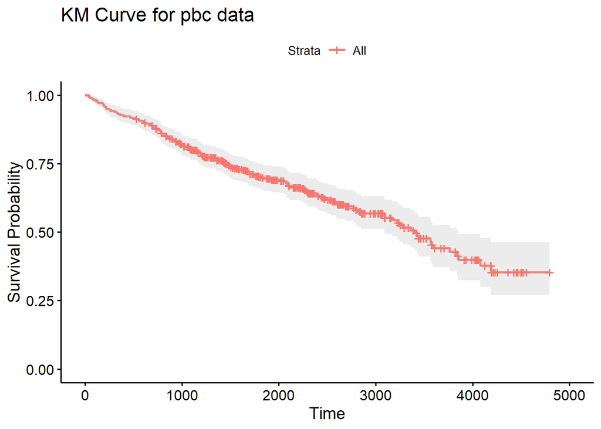

```r
ggsurvplot(fit, conf.int=TRUE,
    xlab = 'Time',
    ylab = 'Survival Probability',
    title = 'KM Curve for pbc data')
```

## 연습문제 5.8

## 42명 백혈병환자에 대한 gehan 데이터(MASS 패키지에 내장됨)에 대해 R을 이용하여 답하시오.

```r
library(survival)
library(MASS)
data(gehan)
head(gehan,10)
```

```
##    pair time cens   treat
## 1     1    1    1 control
## 2     1   10    1    6-MP
## 3     2   22    1 control
## 4     2    7    1    6-MP
## 5     3    3    1 control
## 6     3   32    0    6-MP
## 7     4   12    1 control
## 8     4   23    1    6-MP
## 9     5    8    1 control
## 10    5   22    1    6-MP
```

### (1) 환자 전체에 대한 Kaplan-Meier 생존함수를 구하시오.

```r
fit <- survfit(Surv(time,cens)~1,data=gehan)
summary(fit)
```

```
## Call: survfit(formula = Surv(time, cens) ~ 1, data = gehan)
##
##  time n.risk n.event survival std.err lower 95% CI upper 95% CI
##     1     42       2    0.952  0.0329       0.8901        1.000
##     2     40       2    0.905  0.0453       0.8202        0.998
##     3     38       1    0.881  0.0500       0.7883        0.985
##     4     37       2    0.833  0.0575       0.7279        0.954
##     5     35       2    0.786  0.0633       0.6709        0.920
##     6     33       3    0.714  0.0697       0.5899        0.865
##     7     29       1    0.690  0.0715       0.5628        0.845
##     8     28       4    0.591  0.0764       0.4588        0.762
##    10     23       1    0.565  0.0773       0.4325        0.739
##    11     21       2    0.512  0.0788       0.3783        0.692
##    12     18       2    0.455  0.0796       0.3227        0.641
##    13     16       1    0.426  0.0795       0.2958        0.615
##    15     15       1    0.398  0.0791       0.2694        0.588
##    16     14       1    0.369  0.0784       0.2437        0.560
##    17     13       1    0.341  0.0774       0.2186        0.532
##    22      9       2    0.265  0.0765       0.1507        0.467
##    23      7       2    0.189  0.0710       0.0909        0.395
```

### (2) 환자 전체에 대한 Kaplan-Meier 생존함수를 그림을 그리시오.

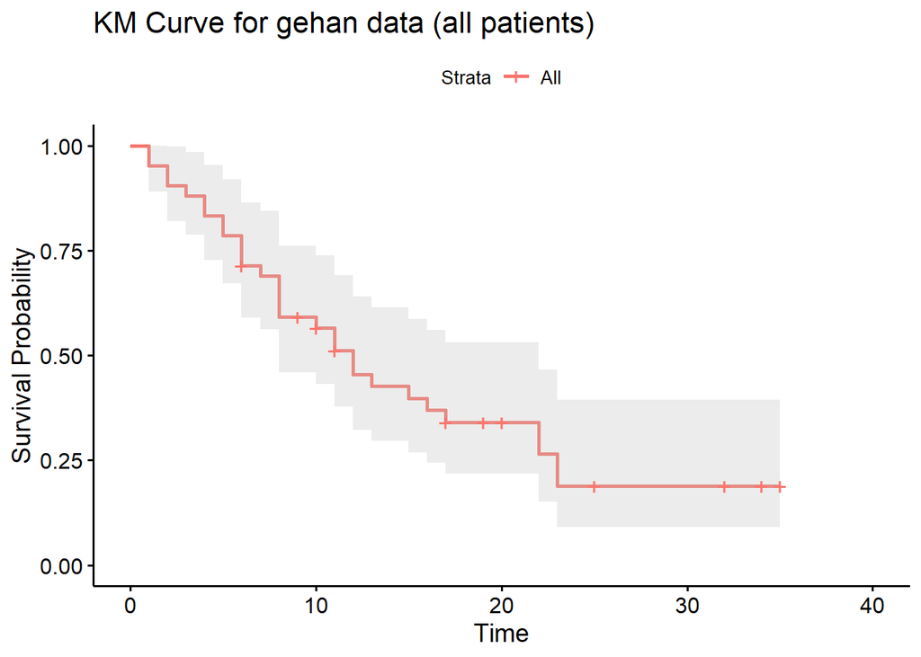

```r
ggsurvplot(fit, conf.int=TRUE,
    xlab = 'Time',
    ylab = 'Survival Probability',
    title='KM Curve for gehan data (all patients)')
```

### (3) control 그룹과 6-MP 그룹별 Kaplan-Meier 생존함수를 구하시오.

```r
fit1 <- survfit(Surv(time,cens)~treat,data=gehan)
summary(fit1)
```

```
## Call: survfit(formula = Surv(time, cens) ~ treat, data = gehan)
##
##                 treat=6-MP
##  time n.risk n.event survival std.err lower 95% CI upper 95% CI
##     6     21       3    0.857  0.0764        0.720        1.000
##     7     17       1    0.807  0.0869        0.653        0.996
##    10     15       1    0.753  0.0963        0.586        0.968
##    13     12       1    0.690  0.1068        0.510        0.935
##    16     11       1    0.627  0.1141        0.439        0.896
##    22      7       1    0.538  0.1282        0.337        0.858
##    23      6       1    0.448  0.1346        0.249        0.807
##
##                 treat=control
##  time n.risk n.event survival std.err lower 95% CI upper 95% CI
##     1     21       2   0.9048  0.0641      0.78754        1.000
##     2     19       2   0.8095  0.0857      0.65785        0.996
##     3     17       1   0.7619  0.0929      0.59988        0.968
##     4     16       2   0.6667  0.1029      0.49268        0.902
##     5     14       2   0.5714  0.1080      0.39455        0.828
##     8     12       4   0.3810  0.1060      0.22085        0.657
##    11      8       2   0.2857  0.0986      0.14529        0.562
##    12      6       2   0.1905  0.0857      0.07887        0.460
##    15      4       1   0.1429  0.0764      0.05011        0.407
##    17      3       1   0.0952  0.0641      0.02549        0.356
##    22      2       1   0.0476  0.0465      0.00703        0.322
##    23      1       1   0.0000     NaN           NA           NA
```

### (4) control 그룹과 6-MP 그룹별 Kaplan-Meier 생존함수 그림을 한 좌표평면에 그리시오.

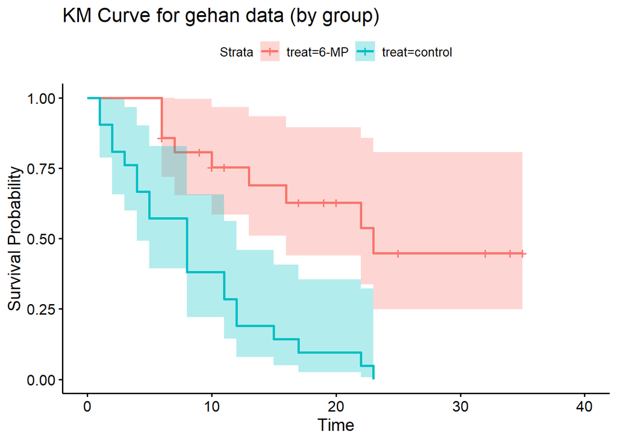

```r
ggsurvplot(fit1, conf.int=TRUE,
    xlab = 'Time',
    ylab = 'Survival Probability',
    title='KM Curve for gehan data (by group)')
```

## 연습문제 5.9

## 다음은 환자 10명에 대한 골수이식 후 사망까지의 데이터이다. 여기서 +는 우중도절단(right-censored)을 의미한다. (R 이용)

```r
library(tidyverse)
library(survival)
library(survminer)
library(gridExtra)
dat1 <- tibble(time=c(11,12,15,44,45,28,16,17,19,30),
               status=c(1,1,1,0,1,0,0,0,0,0))
Surv(dat1$time,dat1$status)
```

```
##  [1] 11  12  15  44+ 45  28+ 16+ 17+ 19+ 30+
```

### (1),(2) Kaplan-Meier 생존함수와 이를 이용한 누적위험함수를 구하시오.

#### S(t)=exp[-H(t)] -> H(t)=-log[S(t)]

```r
fit.K <- survfit(Surv(time,status)~1,type="kaplan",data=dat1)
summary(fit.K)
```

```
## Call: survfit(formula = Surv(time, status) ~ 1, data = dat1, type = "kaplan")
##
##  time n.risk n.event survival std.err lower 95% CI upper 95% CI
##    11     10       1      0.9  0.0949        0.732            1
##    12      9       1      0.8  0.1265        0.587            1
##    15      8       1      0.7  0.1449        0.467            1
##    45      1       1      0.0     NaN           NA           NA
```

```r
fit.K$surv # survival function
```

```
##  [1] 0.9 0.8 0.7 0.7 0.7 0.7 0.7 0.7 0.7 0.0
```

```r
-log(fit.K$surv) # cumulative hazard function
```

```
##  [1] 0.1053605 0.2231436 0.3566749 0.3566749 0.3566749 0.3566749 0.3566749
##  [8] 0.3566749 0.3566749       Inf
```

### (3),(4) Nelson-Aalen 누적위험함수와 이를 이용한 생존함수를 구하시오.

```r
fit.H <- survfit(Surv(time,status)~1,type="fleming",data=dat1)
summary(fit.H)
```

```
## Call: survfit(formula = Surv(time, status) ~ 1, data = dat1, type = "fleming")
##
##  time n.risk n.event survival std.err lower 95% CI upper 95% CI
##    11     10       1    0.905  0.0905       0.7438            1
##    12      9       1    0.810  0.1210       0.6041            1
##    15      8       1    0.715  0.1392       0.4877            1
##    45      1       1    0.263  0.2678       0.0357            1
```

```r
fit.H$surv # survival function
```

```
##  [1] 0.9048374 0.8096841 0.7145437 0.7145437 0.7145437 0.7145437 0.7145437
##  [8] 0.7145437 0.7145437 0.2628659
```

```r
-log(fit.H$surv) # cumulative hazard function
```

```
##  [1] 0.1000000 0.2111111 0.3361111 0.3361111 0.3361111 0.3361111 0.3361111
##  [8] 0.3361111 0.3361111 1.3361111
```

### (5) 한 좌표평면에 (1)과 (4) 그래프를 그리시오.

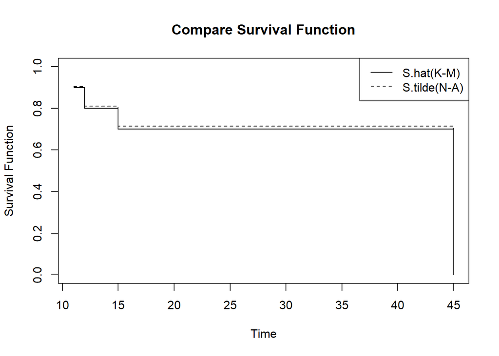

```r
plot(fit.K$time, fit.K$surv,
      xlab="Time", ylab="Survival Function",
     main="Compare Survival Function",
     ylim=c(0,1), type="s")
lines(fit.H$time, fit.H$surv, type="s", lty=2)
legend("topright", legend=c("S.hat(K-M)","S.tilde(N-A)"),lty=c(1,2))
```

### (6) 한 좌표평면에 (2)과 (3) 그래프를 그리시오.

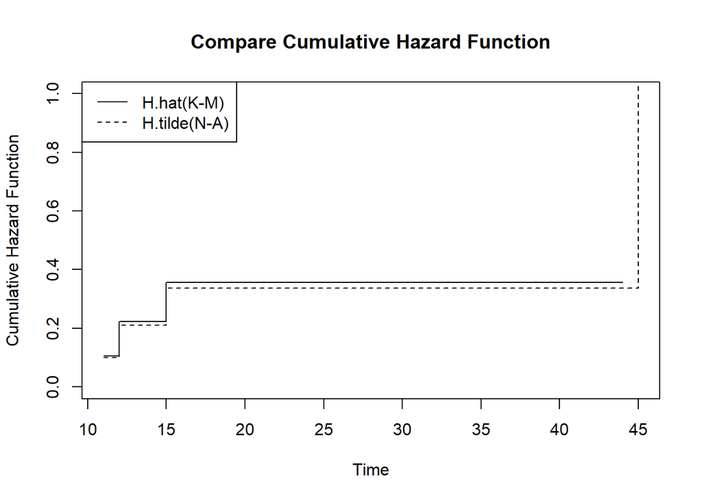

```r
plot(fit.K$time, -log(fit.K$surv),
      xlab="Time", ylab="Cumulative Hazard Function",
     main="Compare Cumulative Hazard Function",
     ylim=c(0,1), type="s")
lines(fit.H$time, -log(fit.H$surv), type="s", lty=2)
legend("topleft", legend=c("H.hat(K-M)","H.tilde(N-A)"),lty=c(1,2))
```

### (7) 95% pointwise linear confidence interval을 구하고 confidence band와 함께 생존함수 그래프를 그리시오.

#### Kaplan-Meier method

```r
fit.K <- survfit(Surv(time,status)~1,type="kaplan",data=dat1)
summary(fit.K)
```

```
## Call: survfit(formula = Surv(time, status) ~ 1, data = dat1, type = "kaplan")
##
##  time n.risk n.event survival std.err lower 95% CI upper 95% CI
##    11     10       1      0.9  0.0949        0.732            1
##    12      9       1      0.8  0.1265        0.587            1
##    15      8       1      0.7  0.1449        0.467            1
##    45      1       1      0.0     NaN           NA           NA
```

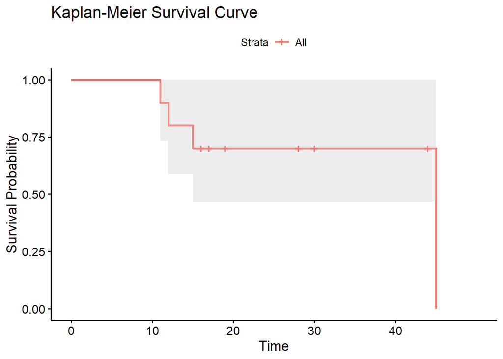

```r
ggsurvplot(fit.K, conf.int=TRUE,
    xlab = 'Time',
    ylab = 'Survival Probability',
    title='Kaplan-Meier Survival Curve')
```

#### Nelson-Aalen method

```r
fit.H <- survfit(Surv(time,status)~1,type="fleming",data=dat1)
summary(fit.H)
```

```
## Call: survfit(formula = Surv(time, status) ~ 1, data = dat1, type = "fleming")
##
##  time n.risk n.event survival std.err lower 95% CI upper 95% CI
##    11     10       1    0.905  0.0905       0.7438            1
##    12      9       1    0.810  0.1210       0.6041            1
##    15      8       1    0.715  0.1392       0.4877            1
##    45      1       1    0.263  0.2678       0.0357            1
```

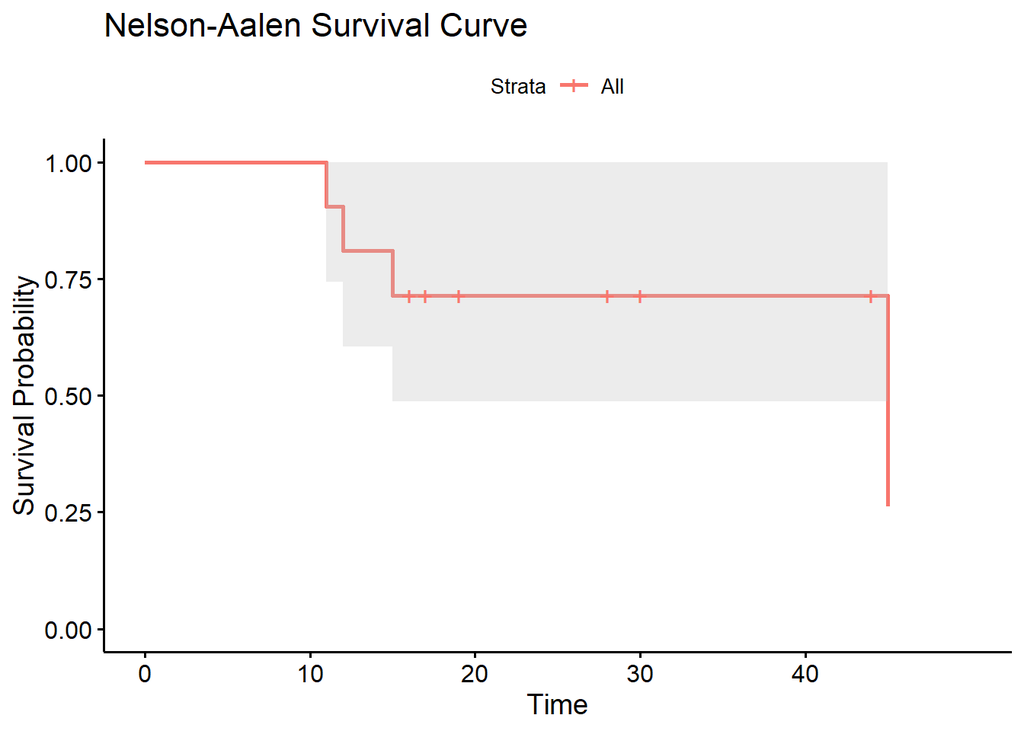

```r
ggsurvplot(fit.H, conf.int=TRUE,
    xlab = 'Time',
    ylab = 'Survival Probability',
    title='Nelson-Aalen Survival Curve')
```